# Problem Set 4

3/9/2017

# Submission

1. Fork this repository to your own account
2. Make changes to the `README.Rmd` file (including the author field above).
3. Knit the file to HTML format
4. Publish HTML on Rpubs (you will need to sign up for the free account) and *add the link below*.
5. Submit a PR with your answers.

# Overview

Take the [datacamp course on joining data](https://www.datacamp.com/courses/joining-data-in-r-with-dplyr) to learn the join verbs.

You will analyze some data in the [`nihexporter`](https://github.com/jayhesselberth/nihexporter) package to answer some questions. The questions will cover methods in `dplyr` including two-table verbs.

First you need to install the `nihexporter` package (and `devtools`, if you don’t have it already).

```r
# install.packages('devtools')
devtools::install_github("jayhesselberth/nihexporter")
```

Read the [Overview vignette](http://jayhesselberth.github.io/nihexporter/articles/nihexporter.html) to learn the structure of the pacakge. Take a look at two tables from the package:

```r
library(nihexporter)
library(tidyverse)
library(broom)

projects
```

```
#> # A tibble: 901,059 × 13
#>    application.id institute activity application.type arra.funded
#>             <int>    <fctr>   <fctr>           <fctr>      <fctr>
#> 1         6258248        CA      C06                1          NA
#> 2         6033399        RR      C06                1          NA
#> 3         6039178        RR      C06                1          NA
#> 4         6258225        RR      C06                1          NA
#> 5         6258259        RR      C06                1          NA
#> 6         6258242        RR      C06                1          NA
#> 7         6258249        RR      C06                1          NA
#> 8         6258264        RR      C06                1          NA
#> 9         6254919        RR      C06                1          NA
#> 10        6254932        RR      C06                1          NA
#> # ... with 901,049 more rows, and 8 more variables: project.num <chr>,
#> #   foa.number <fctr>, fiscal.year <int>, project.start <date>,
#> #   project.end <date>, study.section <fctr>, suffix <fctr>, fy.cost <dbl>
```

```r
project_io
```

```
#> # A tibble: 224,899 × 4
#>    project.num n.pubs n.patents total.cost
#>          <chr>  <int>     <int>      <dbl>
#> 1  C06CA091516      1         1    1488000
#> 2  C06RR013577      1         1     329812
#> 3  C06RR014469      3         1    1000000
#> 4  C06RR014488      1         1    1000000
#> 5  C06RR014489     17         1    1250000
#> 6  C06RR014510      1         1     977434
#> 7  C06RR014517      1         1    1032334
#> 8  C06RR014520      1         1    1000000
#> 9  C06RR014524      1         1    1999999
#> 10 C06RR014527      1         1     852265
#> # ... with 224,889 more rows
```

# Problems

## Problem 1

The `projects` and `project_io` tables have the project.num column in common. Use this column to perform a `left_join` and identify the most expensive project for each institute. Project institutes are in the `projects` table, whereas total project costs are available in the `project_io` table. Note you will have to use the `arrange` and `slice` verbs from `dplyr`.

```r
dplyr::left_join(projects, project_io, by="project.num") %>%
  select(project.num, institute, total.cost) %>%
  group_by(institute) %>%
  arrange(desc(total.cost)) %>%
  slice(1:1) %>%
  arrange(desc(total.cost)) -> answer

answer
```

[output not shown]

## Problem 2

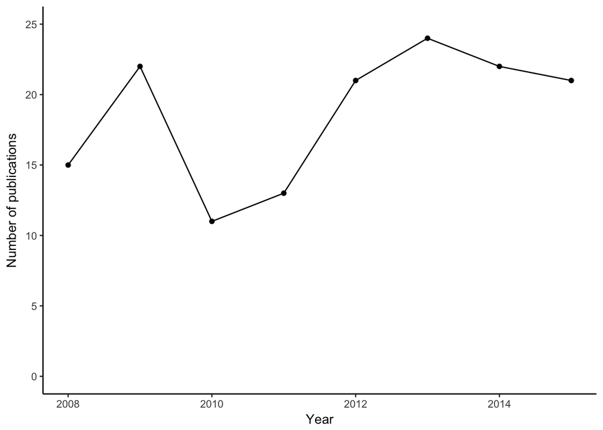

```r
library(cowplot)
dplyr::left_join(projects, project_io, by="project.num") %>%
  select(project.num, institute, total.cost) %>%
  group_by(institute) %>%
  arrange(desc(total.cost)) %>%
  slice(1:1) %>%
  arrange(desc(total.cost)) %>%
  ungroup() %>%
  slice(1:1) %>%
  select(project.num) %>%
  left_join(publinks, by ="project.num") %>%
  left_join(publications, by ="pmid") %>%
  select(pub.year, pmid) %>%
  na.omit() -> final.table

# a line graph
final.table %>%
  group_by(pub.year) %>%
  summarise(total.pubs=n()) %>%
  ggplot(aes(x=pub.year, y=total.pubs)) + geom_point() + geom_line() + ylim(0,25) + labs(x = "Year", y = "Number of publications") + theme_classic()
```

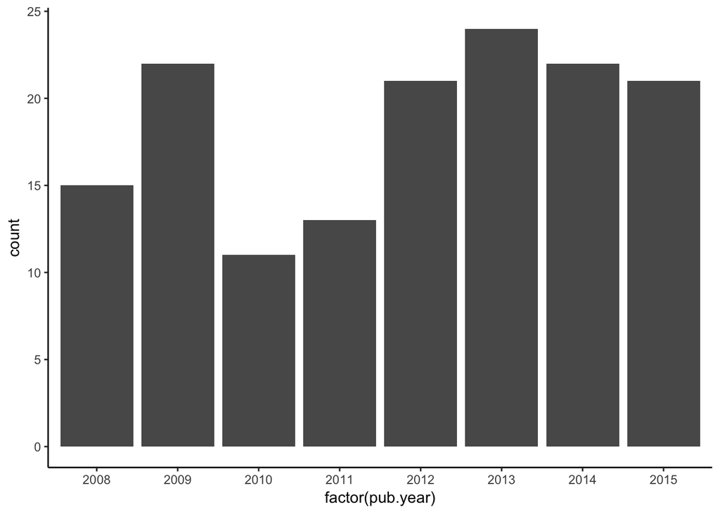

```r
# a bar graph
final.table %>%
  ggplot(aes(factor(pub.year))) + geom_bar() + theme_classic()
```

## Problem 3

Use the `projects` and `clinical_studies` table to calculate how many clinical studies have been started by projects from each institute.

```r
projects %>%
  select(project.num, institute) %>%
  inner_join(clinical_studies, by = "project.num") %>%
  group_by(institute) %>%
  summarise(total.trials = n_distinct(trial.id)) %>%
  arrange(desc(total.trials))-> total.trials

total.trials
```

```
#> # A tibble: 25 × 2
#>    institute total.trials
#>       <fctr>        <int>
#> 1         CA         5232
#> 2         HL         1751
#> 3         MH         1448
#> 4         DA         1157
#> 5         DK          915
#> 6         HD          756
#> 7         AT          559
#> 8         AG          519
#> 9         AI          419
#> 10        NS          378
#> # ... with 15 more rows
```

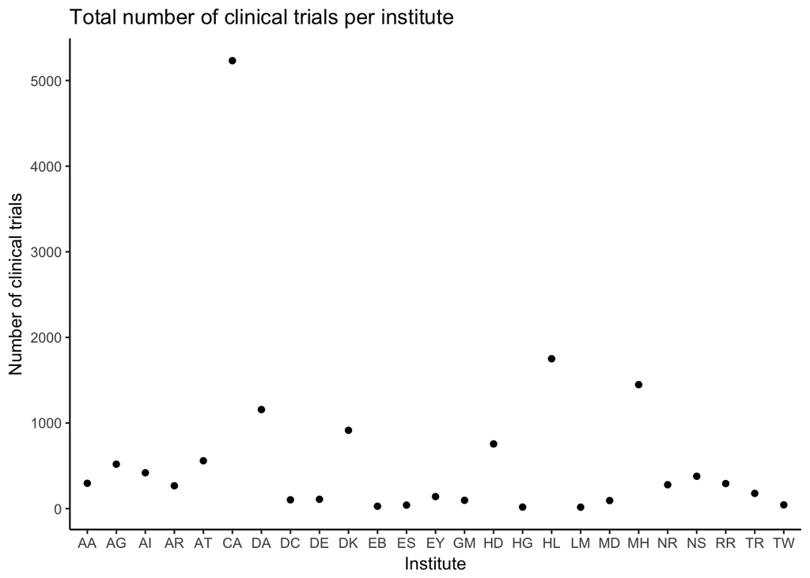

```r
total.trials %>%
  ggplot(aes(x=institute, y=total.trials)) + geom_point() + labs(title = "Total number of clinical trials per institute", x = "Institute", y = "Number of clinical trials") + theme_classic()
```

## Problem 4

Calculate correlations between `total.cost` and `n.pubs` for each institute. You will need to `join` the `projects` and `project_io` tables to link `institute` with `total.cost` and `n.pubs`. You will then need to use `group_by` and `do` from `dplyr` and `tidy` from `broom` to calculate correlations.

```r
projects %>%
  left_join(project_io) %>%
  filter(!duplicated(project.num), !is.na(n.pubs), !is.na(total.cost)) %>%
  select(institute,project.num,fiscal.year, fy.cost, n.pubs, n.patents, total.cost) %>%
  arrange(institute, project.num) -> tab


tab %>%
  group_by(institute) %>%
  do(tidy(cor(.$n.pubs, .$total.cost))) -> result

result
```

[output not shown]

## Problem 5 (extra credit)

Correlate [`rcr`](https://icite.od.nih.gov/) values from the `publications` table to one of:

- total cost (overall for NIH, or by institute)
- budget mechanism (e.g., RFA, PAR, etc.)
- type of grant (e.g. R01, P01, R21, etc.).

```r
publinks %>%
  left_join(publications, by ="pmid") %>%
  left_join(projects, by ="project.num") %>%
  select(institute, project.num, activity, pmid, rcr) %>%
  na.omit() -> rcr.table

rcr.table
```

```
#> # A tibble: 24,604,181 × 5
#>    institute project.num activity     pmid      rcr
#>       <fctr>       <chr>   <fctr>    <int>    <dbl>
#> 1         RR C06RR014469      C06 17621683 0.927150
#> 2         RR C06RR014469      C06 24059281 1.221055
#> 3         RR C06RR014469      C06 24976670 0.470547
#> 4         RR C06RR014469      C06 25980177 0.405393
#> 5         RR C06RR014489      C06 16200579 1.990231
#> 6         RR C06RR014489      C06 16192645 3.040031
#> 7         RR C06RR014489      C06 16059633 1.032259
#> 8         RR C06RR014489      C06 15872085 2.603867
#> 9         RR C06RR014489      C06 16002251 1.017025
#> 10        RR C06RR014489      C06 16234975 7.211317
#> # ... with 24,604,171 more rows
```

```r
rcr.table %>%
  group_by(activity) %>%
  summarise(n.pub = n(), median.rcr = median(rcr), mean.rcr = mean(rcr), min.rcr = min(rcr), max.rcr=max(rcr)) %>%
  rename(grant = activity) %>%
  arrange(desc(n.pub))
```

```
#> # A tibble: 154 × 6
#>     grant   n.pub median.rcr mean.rcr min.rcr   max.rcr
#>    <fctr>   <int>      <dbl>    <dbl>   <dbl>     <dbl>
#> 1     R01 9572001   1.147641 2.017117       0 1330.4491
#> 2     P30 4119272   1.073715 1.969296       0  235.3096
#> 3     T32 1646600   1.091107 1.899937       0  253.7495
#> 4     P01 1495422   1.235473 2.224052       0  398.3514
#> 5     U01  928790   1.356669 2.624244       0  309.5266
#> 6     P50  873442   1.347864 2.553361       0  168.4233
#> 7     R37  612591   1.320472 2.450805       0  204.9630
#> 8     ZIA  529732   1.195404 2.276984       0  276.3978
#> 9     U10  519934   1.416343 3.073635       0  197.1685
#> 10    M01  364845   1.271357 2.257545       0  219.5835
#> # ... with 144 more rows
```

## Problem 6 (extra extra credit)

Use [`gganimate`](https://github.com/dgrtwo/gganimate) to illustrate the change in cost of R01s for a few institutes over time.

```r
# devtools::install_github("dgrtwo/gganimate")
library(gganimate)
projects %>%
  filter(activity == "R01", institute == c("RR", "TW")) %>%
  select(institute, project.num, activity, fiscal.year, project.start, project.end, fy.cost) %>%
  left_join(project_io, by ="project.num") %>%
  na.omit() %>%
  arrange(institute, fiscal.year) -> tmp
```

```
#> I cannot find ImageMagick with convert = 'convert'
```

[figure not shown]

```r
p <- ggplot(tmp, aes(x= total.cost, y= fy.cost, size = n.pubs, color = institute, frame = fiscal.year)) +
  geom_point() +
  scale_x_log10()

gganimate(p, "animated.gif")
```